# Week 6 Regression Report Sample

For this sample report, I’ll use a portion of `R`’s built-in data set `mtcars`. I created a data file with five of the variables from that set for the purposes of this sample report.

## Question

Can we predict the mpg of a car from its engine displacement, horsepower, weight, and number of gears?

## Understanding the Data

We load the data set.

```r
library(tidyverse)
```

```r
myData <- read_csv("carmpg.csv")
attach(myData)
head(myData)
```

```
# A tibble: 6 x 5
    mpg  disp    hp    wt  gear
  <dbl> <dbl> <dbl> <dbl> <dbl>
1  21     160   110  2.62     4
2  21     160   110  2.88     4
3  22.8   108    93  2.32     4
4  21.4   258   110  3.22     3
5  18.7   360   175  3.44     3
6  18.1   225   105  3.46     3
```

```r
summary(myData)
```

```
      mpg             disp             hp              wt
 Min.   :10.40   Min.   : 71.1   Min.   : 52.0   Min.   :1.513
 1st Qu.:15.43   1st Qu.:120.8   1st Qu.: 96.5   1st Qu.:2.581
 Median :19.20   Median :196.3   Median :123.0   Median :3.325
 Mean   :20.09   Mean   :230.7   Mean   :146.7   Mean   :3.217
 3rd Qu.:22.80   3rd Qu.:326.0   3rd Qu.:180.0   3rd Qu.:3.610
 Max.   :33.90   Max.   :472.0   Max.   :335.0   Max.   :5.424
      gear
 Min.   :3.000
 1st Qu.:3.000
 Median :4.000
 Mean   :3.688
 3rd Qu.:4.000
 Max.   :5.000
```

The variable `gear` only has three values which seems to suggest that we should treat it as a categorical variable, not numerical. We can tell `R` to do this by specifying that `gear` is a factor. This will tell `R` to create dummy variables when making the model.

```r
new_gear <- factor(gear)
```

We check the correlation between the other variables.

```r
cor( data.frame(mpg, disp, hp, wt) )
```

```
            mpg       disp         hp         wt
mpg   1.0000000 -0.8475514 -0.7761684 -0.8676594
disp -0.8475514  1.0000000  0.7909486  0.8879799
hp   -0.7761684  0.7909486  1.0000000  0.6587479
wt   -0.8676594  0.8879799  0.6587479  1.0000000
```

These all seem to have fairly stron linear relationships to `mpg`.

We will the scatterplots now.

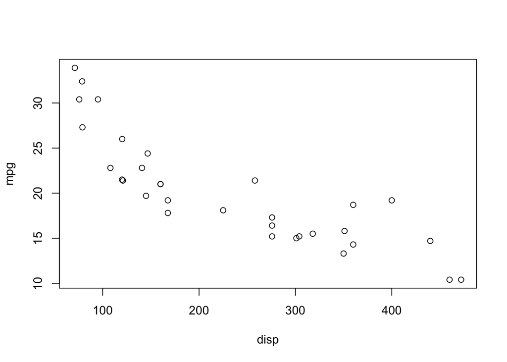

```r
plot(mpg ~ disp)
```

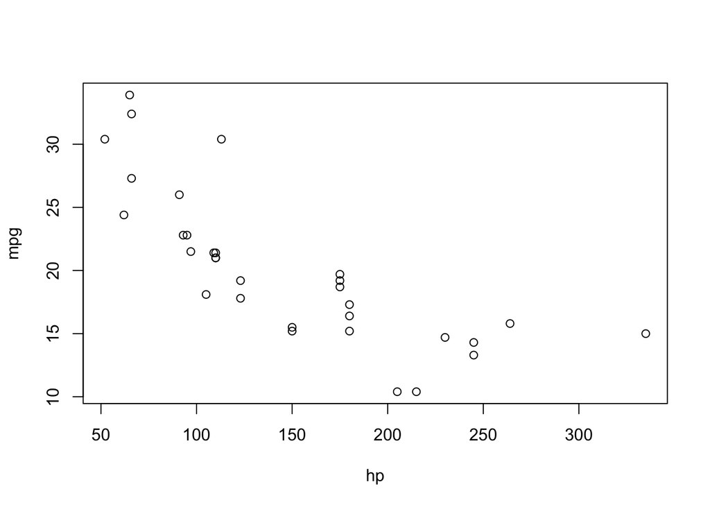

```r
plot(mpg ~ hp)
```

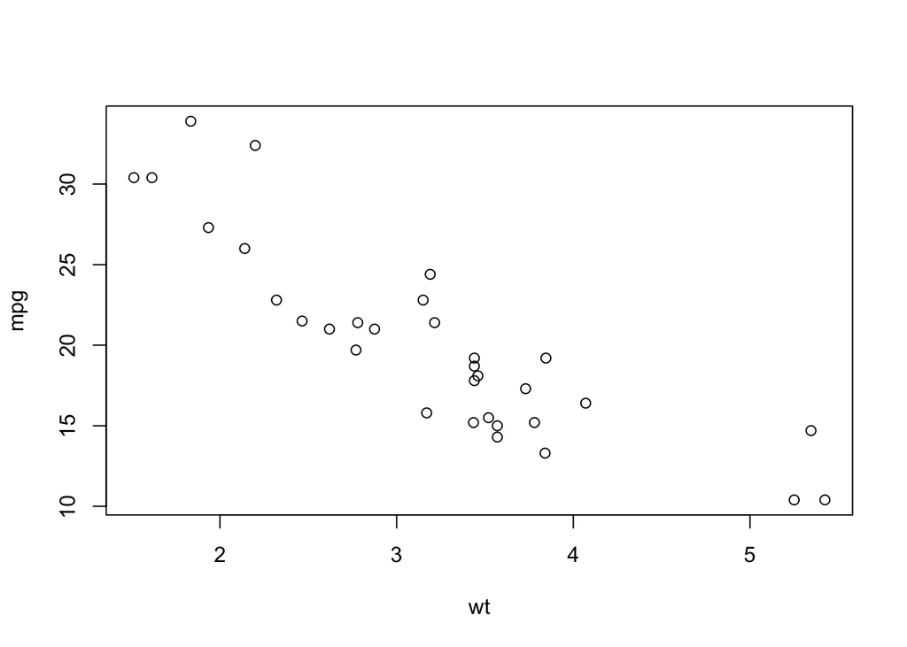

```r
plot(mpg ~ wt)
```

Displacement and horsepower both show some non-linearity. We will transform both and then attempt to build the model.

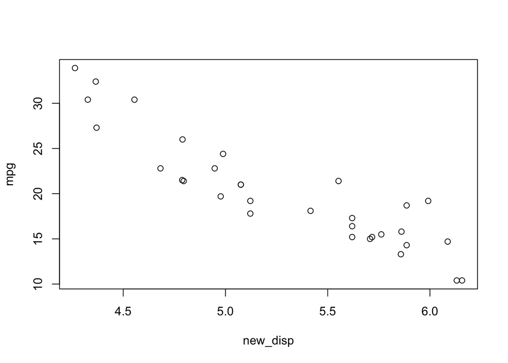

```r
new_disp <- log(disp)
new_hp <- log(hp)

plot(mpg ~ new_disp)
```

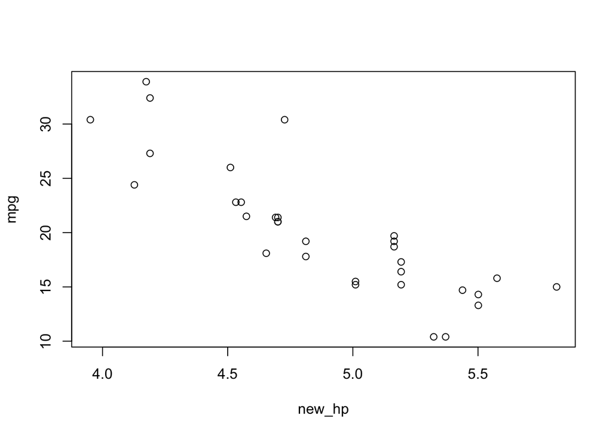

```r
plot(mpg ~ new_hp)
```

These scatterplots show a much more linear relationship. We check the correlation coefficients to verify:

```r
cor( data.frame(mpg, new_disp, new_hp, wt) )
```

```
                mpg   new_disp     new_hp         wt
mpg       1.0000000 -0.9071119 -0.8487707 -0.8676594
new_disp -0.9071119  1.0000000  0.8617723  0.8845389
new_hp   -0.8487707  0.8617723  1.0000000  0.7158277
wt       -0.8676594  0.8845389  0.7158277  1.0000000
```

The correlation coefficients for `mpg` with both `new_disp` and `new_hp` have increased.

## Building the Model

Finally we are ready to generate our first model. We will use all variables initially then use backward elimnation to remove unnecessary variables.

```r
mpgModel <- lm( mpg ~ new_disp + new_hp + wt + new_gear)
summary(mpgModel)
```

```
Call:
lm(formula = mpg ~ new_disp + new_hp + wt + new_gear)

Residuals:
    Min      1Q  Median      3Q     Max
-3.2294 -1.1997 -0.4561  0.6932  4.8744

Coefficients:
            Estimate Std. Error t value Pr(>|t|)
(Intercept)   70.080      8.964   7.818 2.71e-08 ***
new_disp      -3.137      2.569  -1.221   0.2329
new_hp        -5.703      2.255  -2.529   0.0178 *
wt            -1.720      1.032  -1.666   0.1077
new_gear4     -0.715      1.461  -0.489   0.6287
new_gear5      1.491      1.734   0.860   0.3976
---
Signif. codes:  0 '***' 0.001 '**' 0.01 '*' 0.05 '.' 0.1 ' ' 1

Residual standard error: 2.313 on 26 degrees of freedom
Multiple R-squared:  0.8764,    Adjusted R-squared:  0.8527
F-statistic: 36.88 on 5 and 26 DF,  p-value: 5.28e-11
```

The variable `new_gear` is the least significant, so we remove it first.

```r
mpgModel <- lm( mpg ~ new_disp + new_hp + wt)
summary(mpgModel)
```

```
Call:
lm(formula = mpg ~ new_disp + new_hp + wt)

Residuals:
    Min      1Q  Median      3Q     Max
-3.0949 -1.4954 -0.3474  0.7356  4.6082

Coefficients:
            Estimate Std. Error t value Pr(>|t|)
(Intercept)  63.8126     5.6977  11.200 7.45e-12 ***
new_disp     -3.0519     2.1093  -1.447   0.1590
new_hp       -4.1506     1.7443  -2.380   0.0244 *
wt           -2.2784     0.9213  -2.473   0.0197 *
---
Signif. codes:  0 '***' 0.001 '**' 0.01 '*' 0.05 '.' 0.1 ' ' 1

Residual standard error: 2.296 on 28 degrees of freedom
Multiple R-squared:  0.8689,    Adjusted R-squared:  0.8549
F-statistic: 61.88 on 3 and 28 DF,  p-value: 1.791e-12
```

The transformed displacement does not seem significant. We remove it.

```r
mpgModel <- lm( mpg ~ new_hp + wt)
summary(mpgModel)
```

```
Call:
lm(formula = mpg ~ new_hp + wt)

Residuals:
    Min      1Q  Median      3Q     Max
-3.4130 -1.2642 -0.3679  0.7902  5.0780

Coefficients:
            Estimate Std. Error t value Pr(>|t|)
(Intercept)  59.5709     4.9769  11.970 9.64e-13 ***
new_hp       -5.9218     1.2658  -4.678 6.20e-05 ***
wt           -3.2856     0.6148  -5.344 9.74e-06 ***
---
Signif. codes:  0 '***' 0.001 '**' 0.01 '*' 0.05 '.' 0.1 ' ' 1

Residual standard error: 2.339 on 29 degrees of freedom
Multiple R-squared:  0.8591,    Adjusted R-squared:  0.8494
F-statistic: 88.44 on 2 and 29 DF,  p-value: 4.542e-13
```

Both of the remaingin variables and the model overall are significant.

## Model Assumptions

We will check model assumptions to see if any more transformations are necessary.

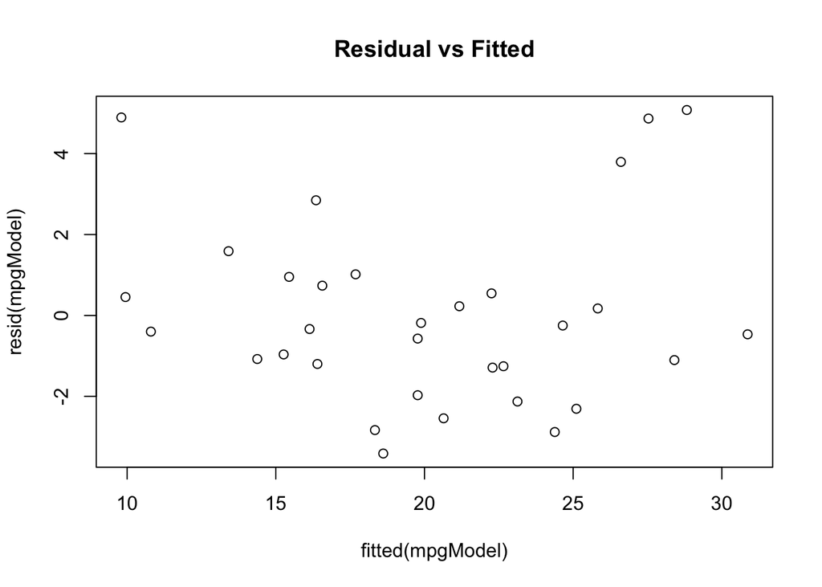

```r
plot(resid(mpgModel) ~ fitted(mpgModel), main="Residual vs Fitted")
```

This is not terrible, but not perfect either. There seems to be some nonlinearity, but the variance seems roughly equal.

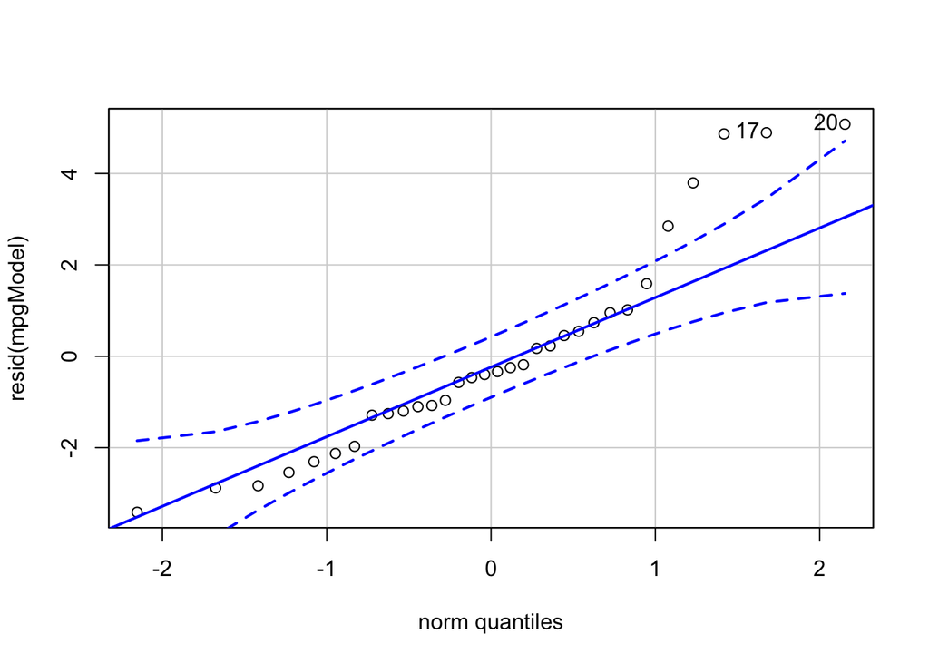

```
[1] 20 17
```

```r
library(car) # this library lets me make the nice plot with dashed lines
qqPlot(resid(mpgModel))
```

There are a several points on the large end that leave the dashed lines. This combined with the residual plot above indicates a data transformation would be helpful. We will perform a `log` transformation on the response variable.

```r
newMpg <- log(mpg)
new_mpgModel <- lm(newMpg ~ new_hp + wt)
summary(new_mpgModel)
```

```
Call:
lm(formula = newMpg ~ new_hp + wt)

Residuals:
     Min       1Q   Median       3Q      Max
-0.16296 -0.07799 -0.02210  0.06837  0.25985

Coefficients:
            Estimate Std. Error t value Pr(>|t|)
(Intercept)  4.83167    0.22198  21.766  < 2e-16 ***
new_hp      -0.26566    0.05646  -4.706 5.75e-05 ***
wt          -0.17942    0.02742  -6.543 3.63e-07 ***
---
Signif. codes:  0 '***' 0.001 '**' 0.01 '*' 0.05 '.' 0.1 ' ' 1

Residual standard error: 0.1043 on 29 degrees of freedom
Multiple R-squared:  0.8852,    Adjusted R-squared:  0.8773
F-statistic: 111.8 on 2 and 29 DF,  p-value: 2.338e-14
```

So far the model looks better with a slightly larger adjusted R-squared and even smaller p-values for several of the variables. Let’s check the model assumptions with some residual plots.

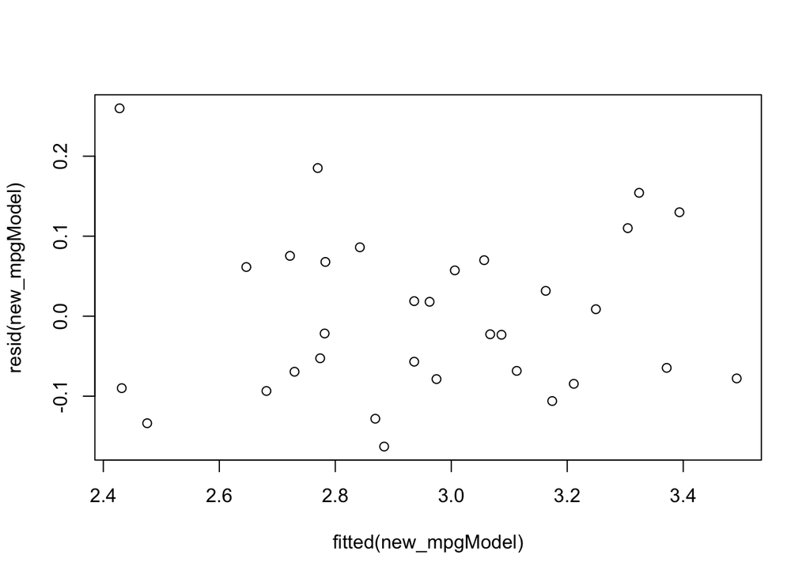

```r
plot(resid(new_mpgModel) ~ fitted(new_mpgModel))
```

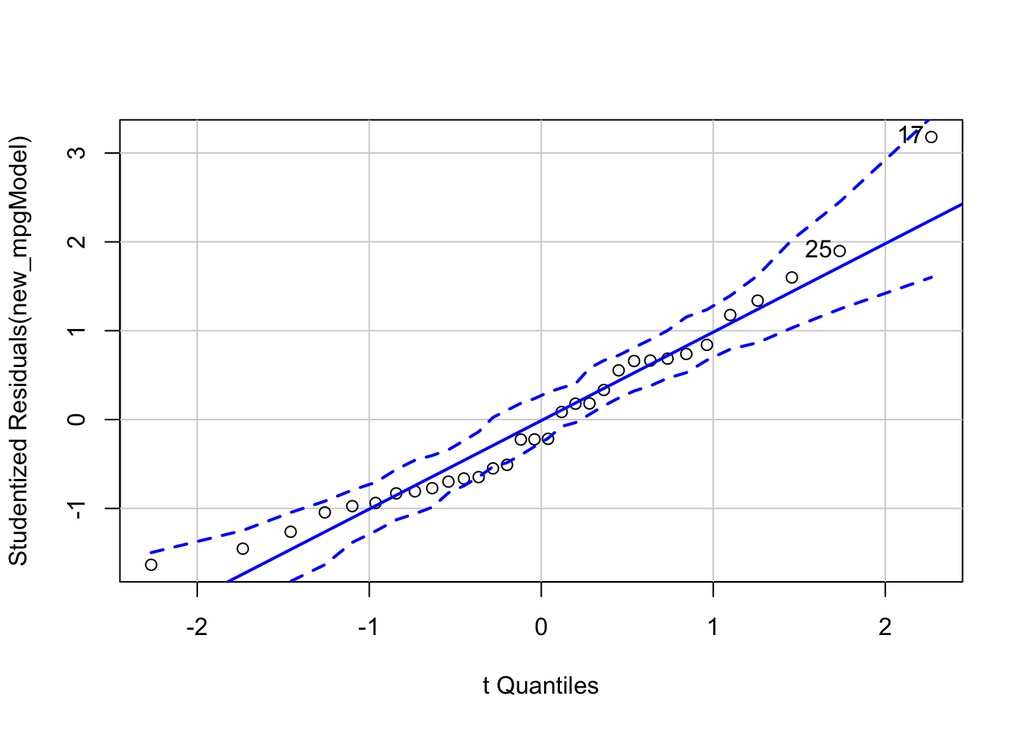

```
[1] 17 25
```

```r
qqPlot(new_mpgModel)
```

These both seem improved. There is no more non-linearity in the residual plots. The normal-probability plot has most of the points very close to the straight line. This seems to be the best model we can construct from this dataset.

## Conclusion

Overall the model meets all assumptions and the R-squared value is rather high at 88%. We should be confident in using this model to predict mpg for cars based on their weight and horsepower.